# Figure 1

# Startup

Load neccessary libraries for this notebook to work and setup basic stuff:

- default graphpad-like theme
- colour palette which includes MEI colours in order: Alu, L1, SVA, PPG, All

# Allele count plot for figures 1A-E

Example script (need to make path changes) to generate MEI files necessary for this project at : `scripts/get_indivTotals.sh`

Also have code at the bottom which prints the averages from Table 1.

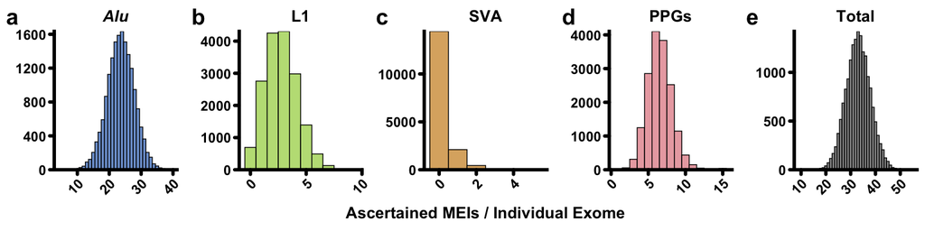

```r
##Import all files
ALU_totals <- fread("RawData/ALU.totals.di.txt")
setnames(ALU_totals,names(ALU_totals),c("ID","Alu","Alu.nc"))
ALU_totals[,Alu.nc:=NULL]
LINE1_totals <- fread("RawData/LINE1.totals.di.txt")
setnames(LINE1_totals,names(LINE1_totals),c("ID","L1","L1.nc"))
LINE1_totals[,L1.nc:=NULL]
SVA_totals <- fread("RawData/SVA.totals.di.txt")
setnames(SVA_totals,names(SVA_totals),c("ID","SVA","SVA.nc"))
SVA_totals[,SVA.nc:=NULL]

## Grab pseudogene information in order to add them to all figures
pseudo_calls <- fread("RawData/Retrogenes.di.txt")

## Get individual IDs from pseudogene vcf and count how many sites per individual and remove dupe individuals
RETROGENE_totals<-data.table(ID=names(pseudo_calls[,5:ncol(pseudo_calls)]),"PPGs"=colSums(pseudo_calls[,5:ncol(pseudo_calls)]))
RETROGENE_totals[,ID:=as.integer(ID)]

## Set any site with greater than 15 sites to NA
fix.outlier<-function(x) {
  if(x <= 15) {
    return(x)
  } else {
    return(NA)
  }
}

RETROGENE_totals[,PPGs:=mapply(fix.outlier,PPGs)]

strsplit.mod<-function(x,y) {
  z<-strsplit(x,y)
  return(z[[1]][2])
}

## Build totals across all 4 RT classes for parents only
totals <- merge(ALU_totals,LINE1_totals,by="ID")
totals <- merge(totals,SVA_totals,by="ID")
totals <- merge(totals,RETROGENE_totals,by="ID")
totals <- totals[,Total:=rowSums(totals[,2:5],na.rm = T)]
totals <- totals[,Total.MEI:=rowSums(totals[,2:4],na.rm = T)]

totals <- data.table(gather(totals,"mei","total",-ID))
totals[,mei:=factor(totals[,mei],levels=c("Alu","L1","SVA","PPGs","Total","Total.MEI"))]

## Make each plot individually
plot.alu.totals <- ggplot(totals[mei=="Alu"],aes(total,fill=mei)) + scale_fill_manual(values=cPalette[1]) + geom_histogram(binwidth=1,colour="black",size=0.25) + xlab(NULL) + ylab(NULL) + scale_y_continuous(expand=c(0,0)) + ggtitle(expression(bolditalic("Alu"))) + theme

plot.l1.totals <- ggplot(totals[mei=="L1"],aes(total,fill=mei)) + scale_fill_manual(values=cPalette[2]) + geom_histogram(binwidth=1,colour="black",size=0.25) + xlab(NULL) + ylab(NULL) + scale_y_continuous(expand=c(0,0)) + scale_x_continuous(breaks = c(0,5,10)) + ggtitle(expression(bold("L1"))) + theme

plot.sva.totals <- ggplot(totals[mei=="SVA"],aes(total,fill=mei)) + scale_fill_manual(values=cPalette[3]) + geom_histogram(binwidth=1,colour="black",size=0.25) + xlab("Ascertained MEIs / Individual Exome") + ylab(NULL) + scale_y_continuous(expand=c(0,0)) + ggtitle(expression(bold("SVA"))) + theme

plot.ppg.totals <- ggplot(totals[mei=="PPGs"],aes(total,fill=mei)) + scale_fill_manual(values=cPalette[4]) + geom_histogram(binwidth=1,colour="black",size=0.25) + xlab(NULL) + ylab(NULL) + scale_y_continuous(expand=c(0,0)) + ggtitle(expression(bold("PPGs"))) + theme

plot.total.totals <- ggplot(totals[mei=="Total"],aes(total,fill=mei)) + scale_fill_manual(values=cPalette[5]) + geom_histogram(binwidth=1,colour="black",size=0.25) + xlab(NULL) + ylab(NULL) + scale_y_continuous(expand=c(0,0)) + ggtitle(expression(bold("Total"))) + theme

figure1.top <- plot_grid(plot.alu.totals,plot.l1.totals,plot.sva.totals,plot.ppg.totals,plot.total.totals,ncol=5,nrow=1,align = 'vh', labels = c("a","b", "c", "d", "e"))
figure1.top
```

```r
## This prints averages from Table 1:
totals[,list(mean(total,na.rm = T),sd(total, na.rm=T)),by="mei"]
```

```
##          mei         V1        V2
## 1:       Alu 23.6137858 4.2463998
## 2:        L1  2.7699624 1.4647265
## 3:       SVA  0.1835956 0.4682947
## 4:      PPGs  6.5501310 1.7058956
## 5:     Total 33.0267144 4.9833193
## 6: Total.MEI 26.5673438 4.6813108
```

# Allele frequency plot for figure 1F

Example script (need to make path changes) to generate MEI files necessary for this project at : `scripts/get_indivTotals.sh`

- To generate input files, code like: vcftools –gzvcf ALU.vcf.gz –keep parents_dddp.unaffected.txt –freq –out ALU –mac 1
- Files generated are:
  - <MEI_NAME>.frq

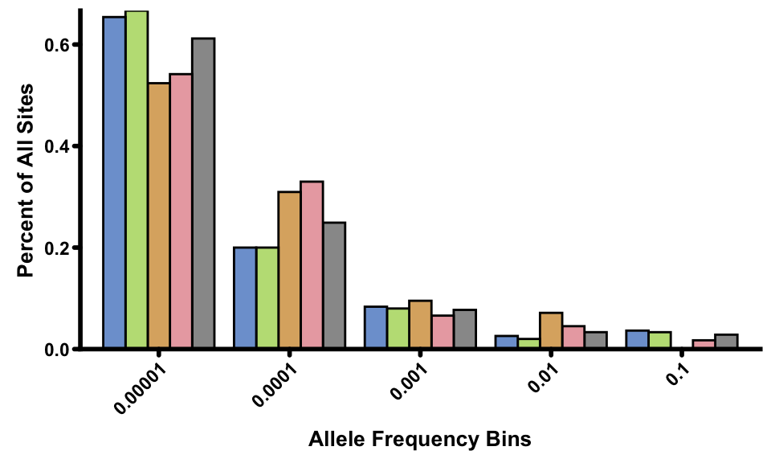

```r
##Import all files
ALU <- fread("RawData/ALU.frq")
LINE1 <- fread("RawData/LINE1.frq")
SVA <- fread("RawData/SVA.frq")

## Get individual IDs and Genes from pseudogene vcf and count how many sites per individual/retrogene
RETROGENE <- data.table(geneid=pseudo_calls[,GENE],N=rowSums(pseudo_calls[,5:ncol(pseudo_calls)]))
total_indv<-ncol(pseudo_calls) - 4 ## minus 4 because of info columns
RETROGENE[,af:=N/total_indv]
RETROGENE[,af.cut:=cut(af,breaks= c(0.00001,0.0001,0.001,0.01,0.1,1))]

ALU[,ac:=apply(ALU,1,function(x) {v<-strsplit(x[6],":",fixed=TRUE);x<-round(as.numeric(v[[1]][4])*as.numeric(x[4]));if(x > 25) {25} else {x}})]
ALU[,af:=apply(ALU,1,function(x) {v<-strsplit(x[6],":",fixed=TRUE);as.numeric(v[[1]][4])})]
ALU[,af.cut:=cut(af,breaks= c(0.00001,0.0001,0.001,0.01,0.1,1))]

LINE1[,ac:=apply(LINE1,1,function(x) {v<-strsplit(x[6],":",fixed=TRUE);x<-round(as.numeric(v[[1]][4])*as.numeric(x[4]));if(x > 25) {25} else {x}})]
LINE1[,af:=apply(LINE1,1,function(x) {v<-strsplit(x[6],":",fixed=TRUE);as.numeric(v[[1]][4])})]
LINE1[,af.cut:=cut(af,breaks= c(0.00001,0.0001,0.001,0.01,0.1,1))]

SVA[,ac:=apply(SVA,1,function(x) {v<-strsplit(x[6],":",fixed=TRUE);x<-round(as.numeric(v[[1]][4])*as.numeric(x[4]));if(x > 25) {25} else {x}})]
SVA[,af:=apply(SVA,1,function(x) {v<-strsplit(x[6],":",fixed=TRUE);as.numeric(v[[1]][4])})]
SVA[,af.cut:=cut(af,breaks= c(0.00001,0.0001,0.001,0.01,0.1,1))]

ac <- bind_rows(ALU,LINE1,SVA)

##Get AF Bins
bins <- data.table(data.table(table(ALU[,af.cut]))[,1])
bins[,ALU:=data.table(table(ALU[,af.cut]))[,2]]
bins[,LINE1:=data.table(table(LINE1[,af.cut]))[,2]]
bins[,SVA:=data.table(table(SVA[,af.cut]))[,2]]
bins[,Retrogene:=data.table(table(RETROGENE[,af.cut]))[,2]]
bins[,Total:=apply(bins,1,function(x){as.numeric(x[2])+as.numeric(x[3])+as.numeric(x[4])+as.numeric(x[5])})]

bins<-data.table(bins=c(bins[,V1],bins[,V1],bins[,V1],bins[,V1],bins[,V1]),
                 counts=c(bins[,ALU],bins[,LINE1],bins[,SVA],bins[,Retrogene],bins[,Total]),
                 MEI=c(rep("ALU",5),rep("LINE1",5),rep("SVA",5),rep("Retrogenes",5),rep("Total",5)))
bins[,pct:=counts/sum(counts),by=MEI]
bins<-data.frame(bins)
bins$MEI2<-factor(bins$MEI,levels=c("ALU","LINE1","SVA","Retrogenes","Total"))
bins$bins2<-factor(bins$bins,levels=c("(1e-05,0.0001]","(0.0001,0.001]","(0.001,0.01]","(0.01,0.1]","(0.1,1]"))
bins<-data.table(bins)

plot.af<-ggplot(bins,aes(bins2,pct,group=MEI2,fill=MEI2)) + scale_fill_manual(values=cPalette) + geom_col(position=position_dodge(width=0.85), width=0.85, colour="black", size=0.5) + scale_x_discrete(labels=c("0.00001","0.0001","0.001","0.01","0.1")) + scale_y_continuous(expand=c(0,0),breaks=c(0,0.2,0.4,0.6)) + theme + xlab("Allele Frequency Bins") + ylab("Percent of All Sites")
plot.af
```

## Figure 1a-e with Poisson distributions

Plots with the Poisson dist. overlayed over each MEI in order Alu, L1, SVA, PPG, Total

These are included as Supplemental Figure 3

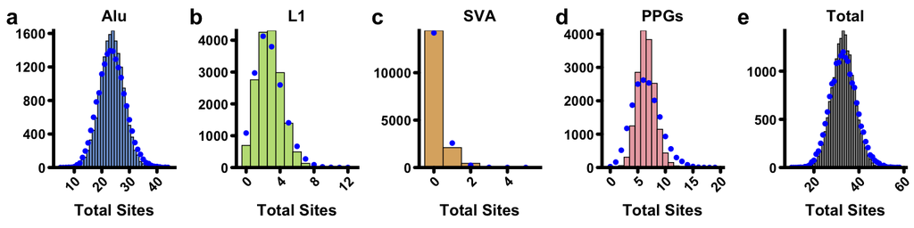

```r
#This code will plot Poisson distribution over each histogram.
mei.types<-c("Alu","L1","SVA","PPGs","Total")
plot.table<-data.table(mei=mei.types,colour=c(1:5))

draw.graph <- function(current.mei,num) {

  mean.mei <- totals[mei==current.mei,mean(total,na.rm=T)]
  total.samples <- length(unique(totals[,ID]))
  max <- max(totals[mei==current.mei,total],na.rm = T)

  # This is a random Poisson deviate to plot alongside the main figures.
  pois.hist <- data.table(rpois(total.samples,lambda=mean.mei))

  plot <- ggplot(totals[mei==current.mei]) +
    geom_histogram(aes(x=total),fill=cPalette[num],colour="black",size=0.25,binwidth=1, center = 1) +
    scale_y_continuous(expand=c(0,0), name = NULL) +
    xlab("Total Sites") +
    stat_bin(inherit.aes=F,data=pois.hist,aes(V1),geom="point",size=1,colour="blue",binwidth=1) +
    ggtitle(current.mei) +
    theme
  return(list(list(plot)))

}
plot.table[,graph:=draw.graph(mei,colour),by=mei]

figure.poisson <- plot_grid(plot.table[mei=="Alu",graph][[1]],
                            plot.table[mei=="L1",graph][[1]],
                            plot.table[mei=="SVA",graph][[1]],
                            plot.table[mei=="PPGs",graph][[1]],
                            plot.table[mei=="Total",graph][[1]],
                            ncol=5,nrow=1,align = 'vh', labels = c("a","b", "c", "d", "e"))
figure.poisson
```

# Length Plot for Figure1G

Example script (need to make path changes) to generate MEI files necessary for this project at : `scripts/get_len.sh`

- Data for the supplied text files runs code like: `bcftools query $MEI.tot.recode.vcf.gz -f "%SVLEN\n" | grep -v "\-1" > $MEI.len`
- Variants are pulled from the VCF file using VCF tools and then processed using BCFTools
- Files generated are:
  - <MEI_NAME>.len

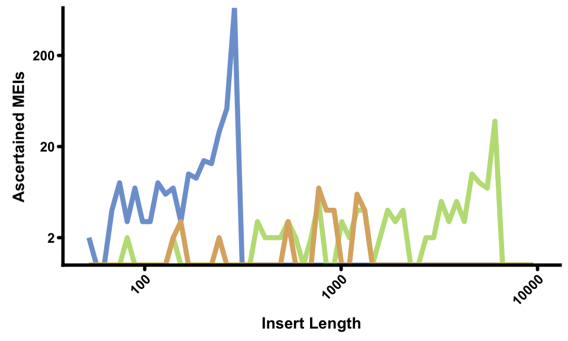

```r
##Import all files
##Generated by (obviously change for MEI type):
ALU_len <- fread("RawData/ALU.len")
ALU_len[,mei:="ALU"]
LINE1_len <- fread("RawData/LINE1.len")
LINE1_len[,mei:="LINE1"]
SVA_len <- fread("RawData/SVA.len")
SVA_len[,mei:="SVA"]

histo <- bind_rows(ALU_len,LINE1_len,SVA_len)
setnames(histo,"V1","lens")

## This is just here to check the proportion of FL-L1s. Print the table "test" if you want to see the raw percentages per-bin.
LINE1_len[,len.cut:=cut(V1,breaks= c(1:1204)*5)]
test<-data.table(table(LINE1_len[,len.cut]))
test[,len.pct:=N/sum(N)]

plot.len<-ggplot(histo,aes(lens,group=mei,colour=mei)) + scale_colour_manual(values=cPalette) + geom_freqpoly(size=1.5,bins=60) + scale_x_log10(breaks=c(100,1000,10000),limits=c(50,10000)) + scale_y_log10(expand=c(0,0),breaks=c(2,20,200)) + theme + xlab("Insert Length") + ylab("Ascertained MEIs")
plot.len
```

## Allele count plot for bait regions

This figure is in the paper as Supplemental Fig. 11. It displayes the allele frequency distribution for RT events and SNVs only in the accesibility mask regions as described in the paper methods.

See `Figure2.rmd` and paper methods for more details on how QC’d SNV calls are made.

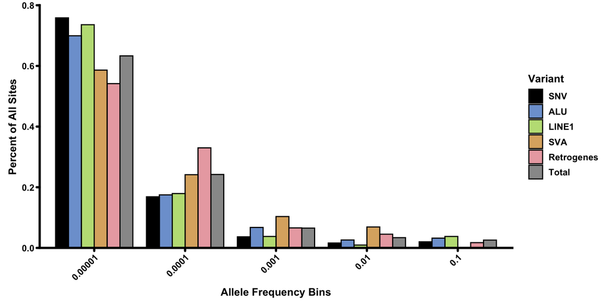

```r
## Add SNV colour to cPalette
cPalette.snv <- c("#000000", cPalette)

##Import all files
ALU <- fread("RawData/ALU.bait.frq")
LINE1 <- fread("RawData/LINE1.bait.frq")
SVA <- fread("RawData/SVA.bait.frq")
SNP <- fread("RawData/SNV.frq")
setnames(SNP,names(SNP),"af")

## Get individual IDs and Genes from pseudogene vcf and count how many sites per individual/retrogene
RETROGENE <- data.table(geneid=pseudo_calls[,GENE],N=rowSums(pseudo_calls[,5:ncol(pseudo_calls)]))
total_indv<-ncol(pseudo_calls) - 4 ## minus 4 because of info columns
RETROGENE[,af:=N/total_indv]
RETROGENE[,af.cut:=cut(af,breaks= c(0.00001,0.0001,0.001,0.01,0.1,1))]

ALU[,ac:=apply(ALU,1,function(x) {v<-strsplit(x[6],":",fixed=TRUE);x<-round(as.numeric(v[[1]][4])*as.numeric(x[4]));if(x > 25) {25} else {x}})]
ALU[,af:=apply(ALU,1,function(x) {v<-strsplit(x[6],":",fixed=TRUE);as.numeric(v[[1]][4])})]
ALU[,af.cut:=cut(af,breaks= c(0.00001,0.0001,0.001,0.01,0.1,1))]

LINE1[,ac:=apply(LINE1,1,function(x) {v<-strsplit(x[6],":",fixed=TRUE);x<-round(as.numeric(v[[1]][4])*as.numeric(x[4]));if(x > 25) {25} else {x}})]
LINE1[,af:=apply(LINE1,1,function(x) {v<-strsplit(x[6],":",fixed=TRUE);as.numeric(v[[1]][4])})]
LINE1[,af.cut:=cut(af,breaks= c(0.00001,0.0001,0.001,0.01,0.1,1))]

SVA[,ac:=apply(SVA,1,function(x) {v<-strsplit(x[6],":",fixed=TRUE);x<-round(as.numeric(v[[1]][4])*as.numeric(x[4]));if(x > 25) {25} else {x}})]
SVA[,af:=apply(SVA,1,function(x) {v<-strsplit(x[6],":",fixed=TRUE);as.numeric(v[[1]][4])})]
SVA[,af.cut:=cut(af,breaks= c(0.00001,0.0001,0.001,0.01,0.1,1))]

SNP[,af.cut:=cut(af,breaks= c(0.00001,0.0001,0.001,0.01,0.1,1))]

ac<-data.frame(ac=c(ALU[,ac],LINE1[,ac],SVA[,ac]),mei=c(rep("Alu",nrow(ALU)),rep("LINE-1",nrow(LINE1)),rep("SVA",nrow(SVA))))

##Get AF Bins
bins <- data.table(data.table(table(ALU[,af.cut]))[,1])
bins[,ALU:=data.table(table(ALU[,af.cut]))[,2]]
bins[,LINE1:=data.table(table(LINE1[,af.cut]))[,2]]
bins[,SVA:=data.table(table(SVA[,af.cut]))[,2]]
bins[,Retrogene:=data.table(table(RETROGENE[,af.cut]))[,2]]
bins[,Total:=apply(bins,1,function(x){as.numeric(x[2])+as.numeric(x[3])+as.numeric(x[4])+as.numeric(x[5])})]
bins[,SNP:=data.table(table(SNP[,af.cut]))[,2]]

bins<-data.table(bins=c(bins[,V1],bins[,V1],bins[,V1],bins[,V1],bins[,V1],bins[,V1]),
                 counts=c(bins[,ALU],bins[,LINE1],bins[,SVA],bins[,Retrogene],bins[,Total],bins[,SNP]),
                 MEI=c(rep("ALU",5),rep("LINE1",5),rep("SVA",5),rep("Retrogenes",5),rep("Total",5),rep("SNV",5)))
bins[,pct:=counts/sum(counts),by=MEI]

bins[,Variant:=factor(MEI,levels=c("SNV","ALU","LINE1","SVA","Retrogenes","Total"))]
bins[,bins:=factor(bins,levels=c("(1e-05,0.0001]","(0.0001,0.001]","(0.001,0.01]","(0.01,0.1]","(0.1,1]"))]


theme<-theme+theme(legend.position="right")
plot <- ggplot(bins,aes(bins,pct,group=Variant,fill=Variant)) + scale_fill_manual(values=cPalette.snv) + geom_col(position=position_dodge(width=0.85), width=0.85, colour="black", size=0.5) + scale_x_discrete(labels=c("0.00001","0.0001","0.001","0.01","0.1")) + scale_y_continuous(expand=c(0,0),breaks=c(0,0.2,0.4,0.6,0.8),limits=c(0,0.8)) + theme + xlab("Allele Frequency Bins") + ylab("Percent of All Sites")

plot
```

# Draw Figure 1

This blob draws figure 1 nicely aligned with cowplot. This still needs a bit of adjustment before can be considered publication ready:

- figure labels are a bit off
- need to add y-axis title to panel ‘a’
- Still not aligning f and a — unsure if there is a way to fix

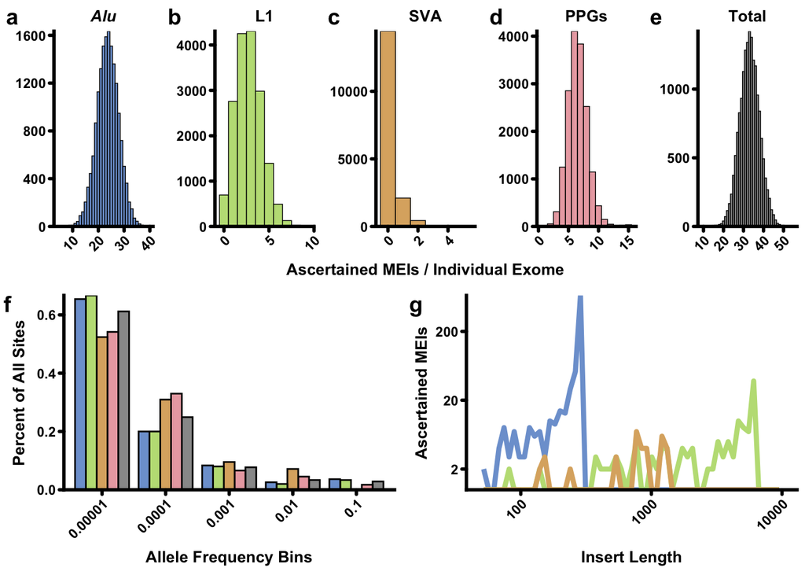

```r
figure1.bot <- plot_grid(plot.af,plot.len,ncol=2,nrow=1,align = 'vh', labels = c("f","g"))
figure1 <- plot_grid(figure1.top,figure1.bot,ncol=1,nrow=2,align='vh')
figure1
```